# Data 605 Assignment 15

Anthony Pagan

May 09 2019

HW15

# Regression

Find the equation of the regression line for the given points. Round any final values to the nearest hundredth, if necessary.

( 5.6, 8.8 ), ( 6.3, 12.4 ), ( 7, 14.8 ), ( 7.7, 18.2 ), ( 8.4, 20.8 )

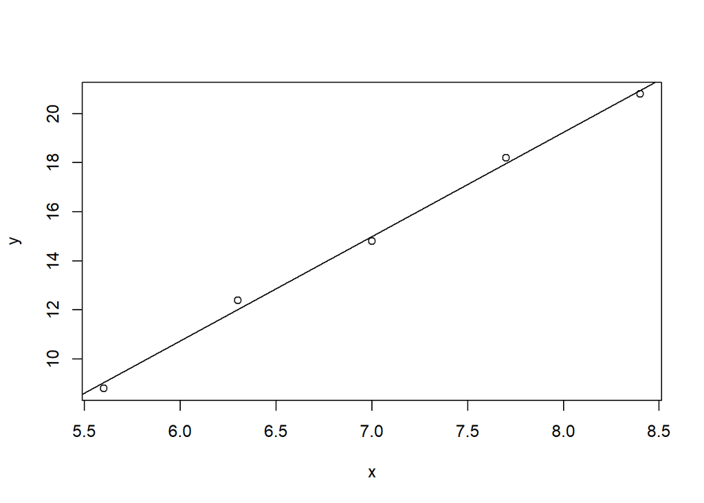

```r
x <-c(5.6,6.3,7,7.7,8.4)
y<-c(8.8,12.4,14.8,18.2,20.8)
l<-lm(y~x)
plot(x,y)
abline(l)
```

**Regression Line: Y = -14.8 + 4.26x**

# Maxima/Minima

${f(x,y)=24x-6xy^2-8y^3}$

- ${f(x)= x -6y^2= 0}$ = ${x = 6y^2}$
- ${f(y)= 12y - 24y = 0}$ = ${y = -12y = \frac{-1}{12}}$

```r
y <--1/12
x <- 6*y^2
z <- 12*x-6*x*y^2-8*y^3
a <- c(x,y,z)
```

# Functions

A grocery store sells two brands of a product, the “house” brand and a “name” brand. The manager estimates that if she sells the “house” brand for x dollars and the “name” brand for y dollars, she will be able to sell 81 - 21x + 17y units of the “house” brand and 40 + 11x - 23y units of the “name” brand.

Step 1. Find the revenue function R ( x, y ).

```r
uh <- 81 - 21*x + 17*y
un <- 40 + 11*x - 23*y
```

**Revenue function = (81 - 21*x + 17*y) + (40 + 11*x - 23*y)**

```r
x <- 2.30
y <- 4.10
R <- uh+un
```

# Minimize Cost

A company has a plant in Los Angeles and a plant in Denver. The firm is committed to produce a total of 96 units of a product each week. The total weekly cost is given by ${C(x, y) = \frac{1}{6}x^2 + \frac{1}{6}y^2+ 7x + 25y + 700}$, where x is the number of units produced in Los Angeles and y is the number of units produced in Denver. How many units should be produced in each plant to minimize the total weekly cost?

- ${f(x)= 2\frac{1}{6}x+7 = 0}$
- ${f(y)= 2\frac{1}{6}x+25 = 0}$

```r
x<-7/(2/6)
y<-25/(2/6)
```

**To minmize weekly cost 21 units should be produced in Los Angeles and 75 units should be producded in Denver**

# Integral

${\int\int_R e^{8x+3y}dA:R:2\le{x}\le{4}}$ and ${2\le{y}\le{4}}$

Write your answer in exact form without decimals.

```r
f<-function(x) { exp(8*x+3*y) }
f2<- function(y) { sapply(y,
function(z) { integrate(f, 2, 4)$value }) }
v<- integrate(f2 , 2, 4)
```